# Thera Bank Personal Loan Campaign - Analysis by Krishna Josyula

## 1. Import the datasets and libraries, check datatype, statistical summary, shape, null values or incorrect imputation

```python
import warnings
```

```python
import numpy as np
from scipy import stats
import pandas as pd
import matplotlib.pyplot as plt
import seaborn as sns
```

```python
from sklearn.model_selection import train_test_split
```

```python
import statsmodels.api as sm

from scipy import stats

from sklearn import metrics
from sklearn.linear_model import LogisticRegression
from sklearn.metrics import classification_report,confusion_matrix
from sklearn.metrics import accuracy_score # Performance measure – Accuracy

from sklearn import preprocessing
```

```python
dfploan=pd.read_csv('Bank_Personal_Loan_Modelling.csv')
dfploan.head()
```

|  | ID | Age | Experience | Income | ZIP Code | Family | CCAvg | Education | Mortgage | Personal Loan | Securities Account | CD Account | Online | CreditCard |
| --- | --- | --- | --- | --- | --- | --- | --- | --- | --- | --- | --- | --- | --- | --- |
| 0 | 1 | 25 | 1 | 49 | 91107 | 4 | 1.6 | 1 | 0 | 0 | 1 | 0 | 0 | 0 |
| 1 | 2 | 45 | 19 | 34 | 90089 | 3 | 1.5 | 1 | 0 | 0 | 1 | 0 | 0 | 0 |
| 2 | 3 | 39 | 15 | 11 | 94720 | 1 | 1.0 | 1 | 0 | 0 | 0 | 0 | 0 | 0 |
| 3 | 4 | 35 | 9 | 100 | 94112 | 1 | 2.7 | 2 | 0 | 0 | 0 | 0 | 0 | 0 |
| 4 | 5 | 35 | 8 | 45 | 91330 | 4 | 1.0 | 2 | 0 | 0 | 0 | 0 | 0 | 1 |

```python
dfploan.shape
```

```
(5000, 14)
```

## 2. EDA: Study the data distribution in each attribute and target variable, share your findings

```python
dfploan.info()
```

```
<class 'pandas.core.frame.DataFrame'>
RangeIndex: 5000 entries, 0 to 4999
Data columns (total 14 columns):
 #   Column              Non-Null Count  Dtype
---  ------              --------------  -----
 0   ID                  5000 non-null   int64
 1   Age                 5000 non-null   int64
 2   Experience          5000 non-null   int64
 3   Income              5000 non-null   int64
 4   ZIP Code            5000 non-null   int64
 5   Family              5000 non-null   int64
 6   CCAvg               5000 non-null   float64
 7   Education           5000 non-null   int64
 8   Mortgage            5000 non-null   int64
 9   Personal Loan       5000 non-null   int64
 10  Securities Account  5000 non-null   int64
 11  CD Account          5000 non-null   int64
 12  Online              5000 non-null   int64
 13  CreditCard          5000 non-null   int64
dtypes: float64(1), int64(13)
memory usage: 547.0 KB
```

```python
#Let's check if there are ane any rows in the given data set with null values
dfploan.isnull().sum()
```

```
ID                    0
Age                   0
Experience            0
Income                0
ZIP Code              0
Family                0
CCAvg                 0
Education             0
Mortgage              0
Personal Loan         0
Securities Account    0
CD Account            0
Online                0
CreditCard            0
dtype: int64
```

Per the output below there are no null values in any of the columns of the dataset

```python
#Let's analyze the distribution of various attributes in the dataset:
dfploan.describe().transpose()
```

|  | count | mean | std | min | 25% | 50% | 75% | max |
| --- | --- | --- | --- | --- | --- | --- | --- | --- |
| ID | 5000.0 | 2500.500000 | 1443.520003 | 1.0 | 1250.75 | 2500.5 | 3750.25 | 5000.0 |
| Age | 5000.0 | 45.338400 | 11.463166 | 23.0 | 35.00 | 45.0 | 55.00 | 67.0 |
| Experience | 5000.0 | 20.104600 | 11.467954 | -3.0 | 10.00 | 20.0 | 30.00 | 43.0 |
| Income | 5000.0 | 73.774200 | 46.033729 | 8.0 | 39.00 | 64.0 | 98.00 | 224.0 |
| ZIP Code | 5000.0 | 93152.503000 | 2121.852197 | 9307.0 | 91911.00 | 93437.0 | 94608.00 | 96651.0 |
| Family | 5000.0 | 2.396400 | 1.147663 | 1.0 | 1.00 | 2.0 | 3.00 | 4.0 |
| CCAvg | 5000.0 | 1.937938 | 1.747659 | 0.0 | 0.70 | 1.5 | 2.50 | 10.0 |
| Education | 5000.0 | 1.881000 | 0.839869 | 1.0 | 1.00 | 2.0 | 3.00 | 3.0 |
| Mortgage | 5000.0 | 56.498800 | 101.713802 | 0.0 | 0.00 | 0.0 | 101.00 | 635.0 |
| Personal Loan | 5000.0 | 0.096000 | 0.294621 | 0.0 | 0.00 | 0.0 | 0.00 | 1.0 |
| Securities Account | 5000.0 | 0.104400 | 0.305809 | 0.0 | 0.00 | 0.0 | 0.00 | 1.0 |
| CD Account | 5000.0 | 0.060400 | 0.238250 | 0.0 | 0.00 | 0.0 | 0.00 | 1.0 |
| Online | 5000.0 | 0.596800 | 0.490589 | 0.0 | 0.00 | 1.0 | 1.00 | 1.0 |
| CreditCard | 5000.0 | 0.294000 | 0.455637 | 0.0 | 0.00 | 0.0 | 1.00 | 1.0 |

#### While data in all columns seem to be real-world experience for some customers is shown as negative years of experience. If experience is not required in model we will drop the columns else we will have to fix the data.

```python
#Number of unique values in each column:
dfploan.nunique()
```

```
ID                    5000
Age                     45
Experience              47
Income                 162
ZIP Code               467
Family                   4
CCAvg                  108
Education                3
Mortgage               347
Personal Loan            2
Securities Account       2
CD Account               2
Online                   2
CreditCard               2
dtype: int64
```

```python
#Number of people with zero mortgage:
dfploan[dfploan['Mortgage']==0]['Mortgage'].count()
```

```
3462
```

Of the given 5000 records nearly 70% of the customers dont have Mortgage

```python
#Number of people with zero credit card spending per month:
dfploan[dfploan['CCAvg']==0]['CCAvg'].count()
```

```
106
```

Just 106 customers of the 5000 have zero credit card spending. Thus 98% of the given sample uses creadit card regularly.

```python
#Value counts for categorical columns - Categorical columns are Education, Personal Loan, Securities Acct, CD Acct, Online, Credit Card
#dfploan[dfploan['Education','Personal Loan','Securities Account','CD Account','Online','CreditCard']].value_counts()
#dfploan['Education','Personal Loan','Securities Account','CD Account','Online','CreditCard'].count()
#df['key1'].value_counts()
#dfploan[['Education','Personal Loan']].value_counts()
list= ['Education','Personal Loan','Securities Account','CD Account','Online','CreditCard']
for i in list:
    x = dfploan[i].value_counts()
    print("Column name is:",i,"and it value is:",x)
    print()
```

```
Column name is: Education and it value is: 1    2096
3    1501
2    1403
Name: Education, dtype: int64

Column name is: Personal Loan and it value is: 0    4520
1     480
Name: Personal Loan, dtype: int64

Column name is: Securities Account and it value is: 0    4478
1     522
Name: Securities Account, dtype: int64

Column name is: CD Account and it value is: 0    4698
1     302
Name: CD Account, dtype: int64

Column name is: Online and it value is: 1    2984
0    2016
Name: Online, dtype: int64

Column name is: CreditCard and it value is: 0    3530
1    1470
Name: CreditCard, dtype: int64
```

Above is shown the distribution of rows for various values of each column. This gives us an understanding of the number of rows of the total 5000 in each category or value of the variable 'Education', 'Personal Loan', Securities Account', 'CD Account', 'Online'and 'CreditCard'

The ID variable can be ignored as it will not have any effect on regression model. As we know customer Id is just to maitain the record in serial order. There is no relationship with Id and Loan. Target Variable is Personal Loan which describe whether the person has taken loan or not. This is the variable which we need to predict. Nonimal Varibles :

ID - Customer ID ZIP Code - Home Address ZIP code of the customer. This variable can also be ignored becasue we can not judge the customers based on thier area or location. Ordinal Categorical variables :

Family - Number of famlily member of the customer Education - Education level of the customer. In our dataset it ranges from 1 to 3 which are Under Graduate, Graduate and Post Graduate respectivly. Interval Variables :

Age - Age of the customer Experience - Years of experience of customer has Income - Annual Income of the customer which is in dollars CCAvg - Avg. spending on credit cards per month which in dollars. Mortgage - Value of House Mortgage Binary Categorical Variable :

CD Account - Does the customer have CD Account with bank or not? Security Account - Does the customer have Security Account with bank or not? Online - Does the customer have Online banking facility with bank or not? Credit Card - Does the customer have a credit card issued by Universal Bank or not? Personal Loan - This our target variable which we have to predict. This indicates that the customer has token loan or not?

```python
dfploannoid=dfploan.drop(['ID','ZIP Code'], axis=1)
dfploannoid
```

|  | Age | Experience | Income | Family | CCAvg | Education | Mortgage | Personal Loan | Securities Account | CD Account | Online | CreditCard |
| --- | --- | --- | --- | --- | --- | --- | --- | --- | --- | --- | --- | --- |
| 0 | 25 | 1 | 49 | 4 | 1.6 | 1 | 0 | 0 | 1 | 0 | 0 | 0 |
| 1 | 45 | 19 | 34 | 3 | 1.5 | 1 | 0 | 0 | 1 | 0 | 0 | 0 |
| 2 | 39 | 15 | 11 | 1 | 1.0 | 1 | 0 | 0 | 0 | 0 | 0 | 0 |
| 3 | 35 | 9 | 100 | 1 | 2.7 | 2 | 0 | 0 | 0 | 0 | 0 | 0 |
| 4 | 35 | 8 | 45 | 4 | 1.0 | 2 | 0 | 0 | 0 | 0 | 0 | 1 |
| ... | ... | ... | ... | ... | ... | ... | ... | ... | ... | ... | ... | ... |
| 4995 | 29 | 3 | 40 | 1 | 1.9 | 3 | 0 | 0 | 0 | 0 | 1 | 0 |
| 4996 | 30 | 4 | 15 | 4 | 0.4 | 1 | 85 | 0 | 0 | 0 | 1 | 0 |
| 4997 | 63 | 39 | 24 | 2 | 0.3 | 3 | 0 | 0 | 0 | 0 | 0 | 0 |
| 4998 | 65 | 40 | 49 | 3 | 0.5 | 2 | 0 | 0 | 0 | 0 | 1 | 0 |
| 4999 | 28 | 4 | 83 | 3 | 0.8 | 1 | 0 | 0 | 0 | 0 | 1 | 1 |

5000 rows × 12 columns

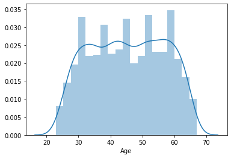

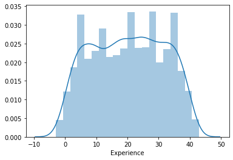

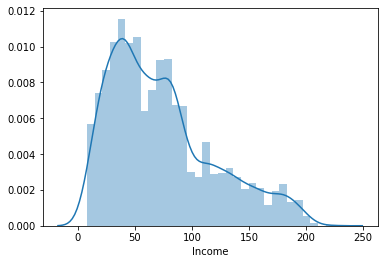

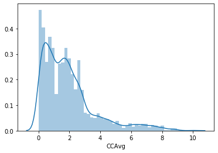

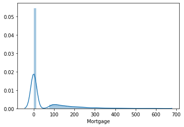

```python
#distplot for continuous columns:
for i in ['Age','Experience','Income','CCAvg','Mortgage']:
    sns.distplot(dfploan[i])
    plt.show()
```

From the above distribution plots we can infer the following:

### Bivariate Analysis

--> In this case-study, we are going to apply Logistic Regression. --> Even before we apply, let's have a look at the data to see how each attribute is different when loan has been offered or not. --> To check it, we will have to use groupby and crosstabs. --> First we will check the pair plots and Heatmap to get a sense of correlation amongst the various attributes.

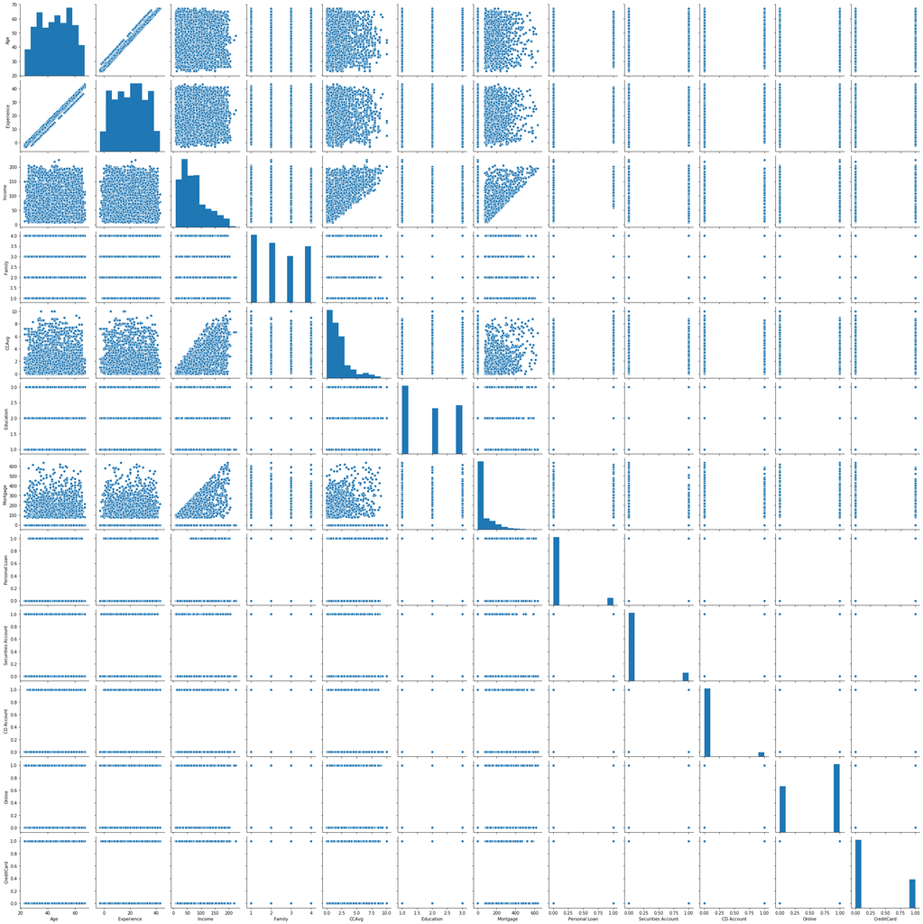

```python
sns.pairplot(dfploannoid)
```

#### From the above scatter plots we can infer the following:

There is a very high positive corelation between age and experience

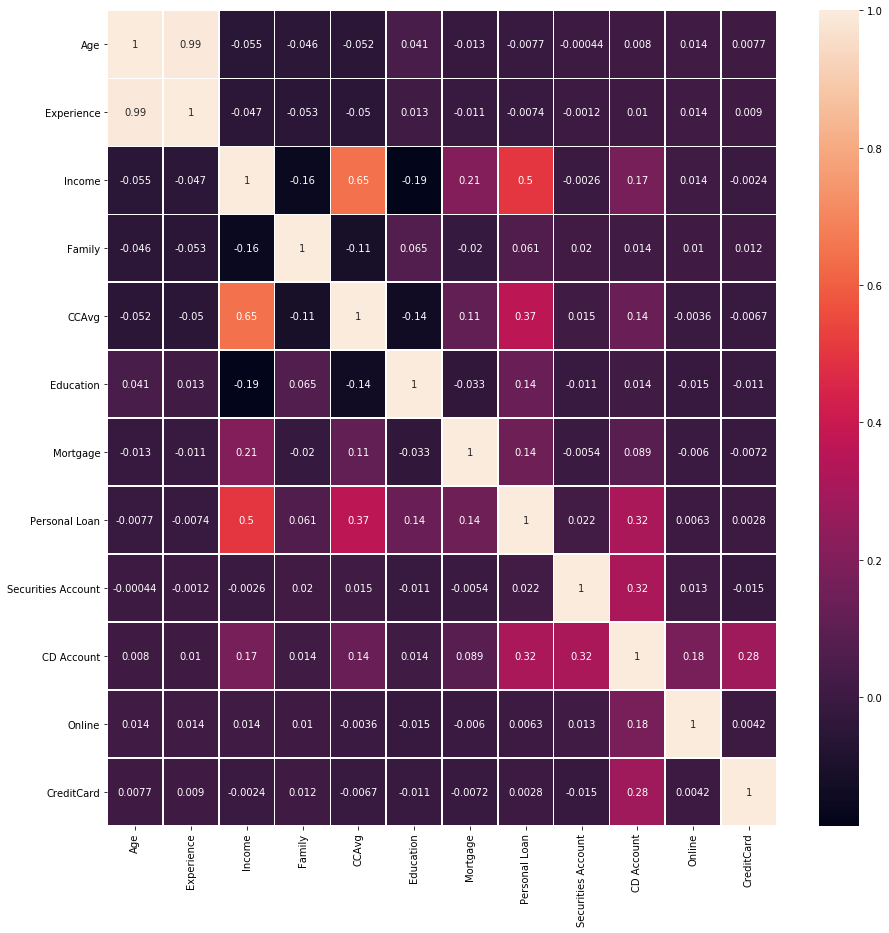

```python
plt.figure(figsize=(15,15))
sns.heatmap(dfploannoid.corr(),annot=True,Linewidths=0.5)
plt.show()
```